# Practical Machine Learning - Course Assignment

Sascha C.

29 Augustus 2016

### Executive summary

This study used [training data from accelerometers on the belt, forearm, arm, and dumbell of 6 participants](http://groupware.les.inf.puc-rio.br/har/), who performed barbell lifts in five different ways. I trained a Random Forest model on the data with 10-fold cross validation in order to predict the manner in which participants did the exercise. The classification accuracy of the final model was 99.95% for the training data.

### 1. Loading data and packages

```r
library(caret);library(parallel);library(doParallel);require(nnet);
training0<- read.csv("pml-training.csv")
testing0<-read.csv("pml-testing.csv")
```

### 2. Preprocessing

The preprocessing was identical for training and test data. The most important steps were:

- Removing predictors with near zero variances
- K nearest neighbor imputation
- Principal Component Analysis (PCA) of the predictors corresponding to accelerometer data. I performed this analysis in order to reduce the number of predictors and because the accelerometer predictors were likely to be correlated. In Figure 1, I plotted the cumulative proportion of explained variance against the number of principal components in the training data. I decided to select a subset of 40 principal components as predictors, since at that point little variance was gained by retaining additional components.

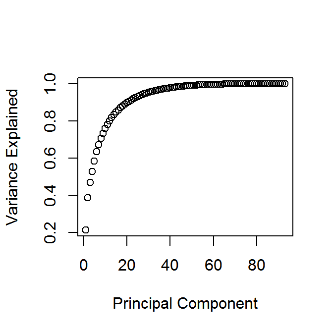

```r
classe<-training0$classe
#Remove near zero variables
nsv <- nearZeroVar(training0,saveMetrics=TRUE)
training1<-training0[,which(nsv$nzv=="FALSE")]
testing1<-testing0[,which(nsv$nzv=="FALSE")]
#Remove  Class variable predictors that do not correspond to accelerometer data
training2<-training1[,-c(1:6,100)]
testing2<-testing1[,-c(1:6,100)]
#knn imputation
knni<-preProcess(training2,method="knnImpute")
training3<-predict(knni,training2)
testing3<-predict(knni,testing2)
#Principal component analysis
pca<-prcomp(training3)
training4<-predict(pca,training3)
testing4<-predict(pca,testing3)
# Combine the first 40 PC's with remaining predictors (except for column 1),
training5<-cbind(training1[,2:6],training4[,1:40])
testing5<-cbind(testing1[,2:6],testing4[,1:40])
plot(summary(pca)$importance[3,],ylab = "Variance Explained", xlab = "Principal Component")
```

### 3. Model fitting and prediction

I fit a Random Forest model on the training data using 10-fold cross validation. Moreover, I allowed for parallel processing to speed up the computation process. For the training data, the average accuracy of the final model in the 10 folds was 99.95%, i.e., the expected out-of-sample error rate was 0.05% (*see confusion matrix below*). The final model was used to predict the classes in the test data.

```r
#Set training options
cvCtrl <- trainControl(method = "cv",
                       number = 10,
                       allowParallel = TRUE)
cluster <- makeCluster(detectCores() - 1)
registerDoParallel(cluster)
#Train model, show confusion matrix, and use model to predict test data
set.seed(111)
if(file.exists("rfModel.Rda")){
  load("rfModel.Rda")} else {
m<-train(classe~.,method="rf",data=training5,trControl=cvCtrl)
}
stopCluster(cluster)
p<-predict(m,testing5)
confusionMatrix.train(m)
```

```
## Cross-Validated (10 fold) Confusion Matrix
##
## (entries are percentual average cell counts across resamples)
##
##           Reference
## Prediction    A    B    C    D    E
##          A 28.4  0.0  0.0  0.0  0.0
##          B  0.0 19.3  0.0  0.0  0.0
##          C  0.0  0.0 17.4  0.0  0.0
##          D  0.0  0.0  0.0 16.4  0.0
##          E  0.0  0.0  0.0  0.0 18.4
##
##  Accuracy (average) : 0.9995
```